# PRS Survey Description

Markus Min

2025-05-20

## Survey objectives and background

The objectives of the pre-recruit survey (PRS) are to:

1. Quantify the environmental conditions and organisms of the Northern California Current (off Oregon and Washington);
2. Study ecosystem-level processes affecting managed and protected marine resources

### Survey methodology

The PRS survey uses multiple sampling methods:

1. CTD casts at ﬁxed stations measure temperature, salinity, density, chlorophyll a, turbidity, and dissolved oxygen throughout the water column (to maximum depth of 500 m)
2. Underway acoustic data are collected continuously throughout the survey to acoustically characterize the distribution and abundance of macrozooplankton, micronekton, meroplankton, and zooplankton
3. Biological sampling is conducted using a modiﬁed Cobb midwater trawl and bongo and Manta nets at ﬁxed cross-shelf stations along ten 0.5◦-latitudinal transects. The midwater trawls have a target headrope depth of 30 m, are ∼15 min in duration, and are conducted at night.
4. Ichthyo- and zooplankton are collected using a bongo net with a 60-cm diameter mouth opening and 333-µm mesh nets.

### Spatial and temporal extent

The PRS began in 2001 as a collaboration between NOAA and the Paciﬁc Whiting Conservation Cooperative (PWCC) and helped complement survey eﬀort by the RREAS oﬀ California. The PWCC surveys sampled at non-fixed locations centered on the shelf break because of the belief that that was where YOY hake were most likely to occur. The PWCC surveys covered the area from Newport, OR to Point Conception in 2001, 2002, and 2003. In 2004, the spatial coverage was expanded to just north of the Columbia River, and in 2005, was again expanded to just south of Cape Flattery (Sakuma et al. 2006). The last year of the PWCC survey was 2009.

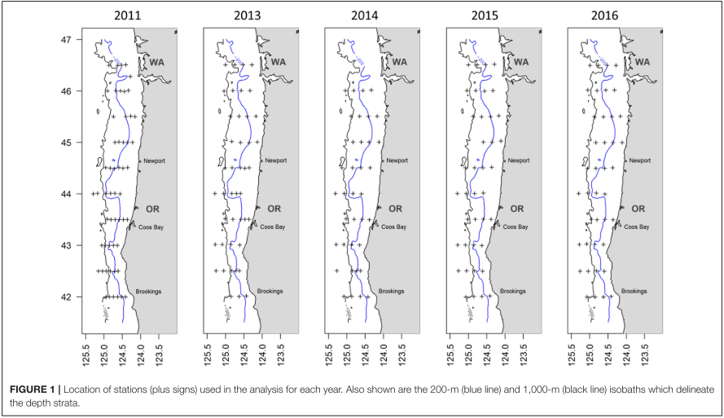

Map of the PRS survey extent from Brodeur et al. (2019).

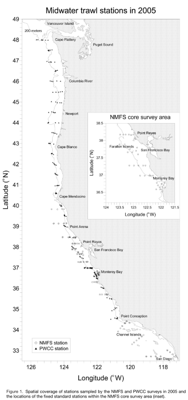

Map of the combined PWCC/RREAS survey extent in 2005 from Sakuma et al. (2006).

### Core taxa

- Euphausiids (>95% of total catch)
- Pink Shrimp *Pandalus jordani*
- Glass shrimp *Sergestes similis*
- Gelatinous zooplankton (e.g., tunicates and hydrozoans)
- Cephalopods (e.g., black-tip squid *Abraliopsis felis* and clawed armhook squid *Gonatus onyx*)
- Various teleost fishes, including:
  - Mesopelagic lanternfish species (e.g., *Stenobrachius leucopsarus* and *Tarletonbeania crenularis*)
  - age-0 Pacific Hake *Merluccius productus*
  - Juvenile rockfishes *Sebastes* spp.
  - Northern anchovy *Engraulis mordax*

#### References

Brodeur, R. D., M. E. Hunsicker, A. Hann, and T. W. Miller. 2019. [Effects of warming ocean conditions on feeding ecology of small pelagic fishes in a coastal upwelling ecosystem: A shift to gelatinous food sources](https://doi.org/10.3354/meps12497). Marine Ecology Progress Series 617-618:149–163.

Sakuma, K. M., S. Ralston, and V. G. Wespestad. 2006. INTERANNUAL AND SPATIAL VARIATION IN THE DISTRIBUTION OF YOUNG-OF-THE-YEAR ROCKFISH (SEBASTES SPP.): EXPANDING AND COORDINATING A SURVEY SAMPLING FRAME.